# Peer-graded Assignment: Final Project Submission

Atasie Diana

5/27/2019

# General Information

The goal of this project is to use a prediction algorithm that I have built and an interface that can be accessed easily by others. For this I have to realize:

- A slide deck consisting of no more than 5 slides created with R Studio Presenter pitching my algorithm and app as if you were presenting to your boss or an investor.
- A Shiny app (https://diana25.shinyapps.io/Final_week7/) that takes as input a phrase (multiple words) in a text box input and outputs a prediction of the next word.

# Packages used

- readr
- stringi
- stringr
- tidytext
- janeaustenr
- dplyr
- readr
- tidytext
- textreadr

# Data used

I used the website https://www.nytimes.com/interactive/2017/06/23/opinion/trumps-lies.html for the prediction algorithm.

```r
 library(textreadr)
    webpage <- read_html("https://www.nytimes.com/interactive/2017/06/23/opinion/trumps-lies.html")
    webpage[c(2,3)]
```

```
## [1] "LEARN MORE »" "Sections"
```

# Short Description of the algorithm

- I used the unnest_tokens function and count function to see which ngrams are more frequent.When someone write a word, the app shows the next word from the more frequent ngrams containning typing word.
- If you type a SPACE, you will receive the message: Type the new word, because the SPACE means that you want to add a new word.
- If we don’t have in the database the typing word you will receive an error message.
- If you want to see the code, you can access the code on https://github.com/DianaAtasie/Final

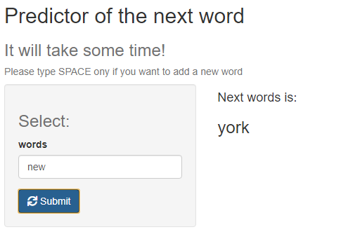